# Data Manipulation with Dplyr

Tim Dennis

January 10, 2016

- we select certain observations (rows) or variables (columns)
- we often group the data by a certain variable(s), or we even calculate summary statistics
- we can do these operations using the normal base R operations:

### Load data

```r
#setwd('~/workshops/r-novice-gapminder/')
#gapminder <- read.csv("https://goo.gl/BtBnPg", header = T)
gapminder <- read.csv("data/gapminder-FiveYearData.csv", header = T)
```

```r
mean(gapminder[gapminder$continent == "Africa", "gdpPercap"])
```

```
## [1] 2193.755
```

```r
mean(gapminder[gapminder$continent == "Americas", "gdpPercap"])
```

```
## [1] 7136.11
```

```r
mean(gapminder[gapminder$continent == "Asia", "gdpPercap"])
```

```
## [1] 7902.15
```

- but not great b/c there’s a fair amount of repetition.
- repeating yourself will take time and also introduce error

## dplyr package

- reduces repetition
- introduces functions to help
- dplyr grammar easier to read

1. select()
2. filter()
3. group_by()
4. summarize()
5. mutate()

Install this package:

```r
#install.packages('dplyr')
library(dplyr)
```

### Select

If we want to **select** just a few varialbes in our data frame.

```r
year_country_gdp <- select(gapminder, year, country, gdpPercap)
```

Show fig 1 in lesson.

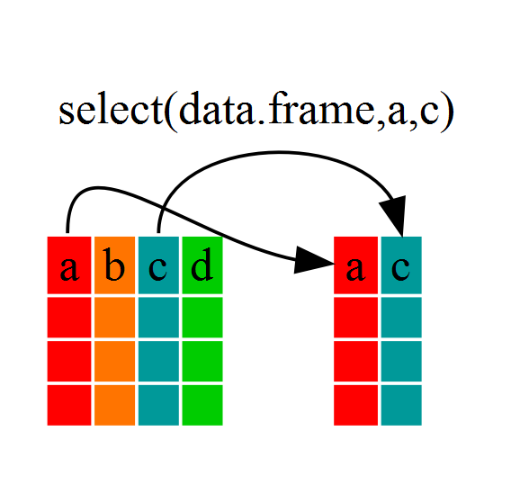

Using pipes (`%>%`), forward pipe left to right, obviates need to include dataframe

```r
year_country_gdp <- gapminder %>% select(year,country,gdpPercap)
```

If we now wanted to move forward with the above, but only with European countries, we can combine select and filter

### Filter

```r
year_country_gdp_euro <- gapminder %>%
  filter(continent == "Europe") %>%
  select(year, country, gdpPercap)
```

- above notice we pass the data from filter to select
- order of operations matter

```r
str(gapminder)
```

```
## 'data.frame':    1704 obs. of  6 variables:
##  $ country  : Factor w/ 142 levels "Afghanistan",..: 1 1 1 1 1 1 1 1 1 1 ...
##  $ year     : int  1952 1957 1962 1967 1972 1977 1982 1987 1992 1997 ...
##  $ pop      : num  8425333 9240934 10267083 11537966 13079460 ...
##  $ continent: Factor w/ 5 levels "Africa","Americas",..: 3 3 3 3 3 3 3 3 3 3 ...
##  $ lifeExp  : num  28.8 30.3 32 34 36.1 ...
##  $ gdpPercap: num  779 821 853 836 740 ...
```

```r
str(gapminder %>% group_by(continent))
```

```
## Classes 'grouped_df', 'tbl_df', 'tbl' and 'data.frame':  1704 obs. of  6 variables:
##  $ country  : Factor w/ 142 levels "Afghanistan",..: 1 1 1 1 1 1 1 1 1 1 ...
##  $ year     : int  1952 1957 1962 1967 1972 1977 1982 1987 1992 1997 ...
##  $ pop      : num  8425333 9240934 10267083 11537966 13079460 ...
##  $ continent: Factor w/ 5 levels "Africa","Americas",..: 3 3 3 3 3 3 3 3 3 3 ...
##  $ lifeExp  : num  28.8 30.3 32 34 36.1 ...
##  $ gdpPercap: num  779 821 853 836 740 ...
##  - attr(*, "vars")=List of 1
##   ..$ : symbol continent
##  - attr(*, "drop")= logi TRUE
##  - attr(*, "indices")=List of 5
##   ..$ : int  24 25 26 27 28 29 30 31 32 33 ...
##   ..$ : int  48 49 50 51 52 53 54 55 56 57 ...
##   ..$ : int  0 1 2 3 4 5 6 7 8 9 ...
##   ..$ : int  12 13 14 15 16 17 18 19 20 21 ...
##   ..$ : int  60 61 62 63 64 65 66 67 68 69 ...
##  - attr(*, "group_sizes")= int  624 300 396 360 24
##  - attr(*, "biggest_group_size")= int 624
##  - attr(*, "labels")='data.frame':   5 obs. of  1 variable:
##   ..$ continent: Factor w/ 5 levels "Africa","Americas",..: 1 2 3 4 5
##   ..- attr(*, "vars")=List of 1
##   .. ..$ : symbol continent
##   ..- attr(*, "drop")= logi TRUE
```